# 36-315 Homework 11, Spring 2020

Solutions

Due Wednesday, April 22, 2020 (11:59pm ET) on Canvas

# Homework 11: Time Series and Final Project EDA

## Problem 1: EDA for Final Project (10pts)

For this problem, all you need to do is turn in one plot using the dataset your team chose for the final project. The plot can be any visual of your choice, but it must at a minimum display three variables. Be sure that your plot is appropriately titled and labeled such that it is clear what you are plotting. After you’ve made your plot, interpret the plot in 2-4 sentences and discuss why you think this plot is informative for the kind of questions you want to answer with your dataset. The best way to complete this question is to take a few days to think about your dataset (possiby discussing with your teammates) and make a few plots that you think are interesting, and then only submit your best plot for this question. You **should not** just try to make an arbitrary multivariate graph as quickly as possible to complete this problem, because if we think your graph/interpretation is not well-motivated given the goals of your project, we may deduct up to 7.5pts for this problem. After this homework, you’ll also be asked to share your graph with your team, so you don’t want to make a graph that you’d be embarrassed to show your teammates.

## Problem 2: Time Series and Dates (34 points)

In this homework, we’ll be using data from the [NYC Citi Bike](https://www.citibikenyc.com/) program. The NYC Citi Bike data is a tremendous resource; see [this page](https://www.citibikenyc.com/system-data) for details about the various datasets that are available. There are tons of data that we could work with here, and we’re just going to work with a small subset. To ensure that no one has issues accessing and/or loading in the very large raw data files, I already subsetted the data for you and uploaded it to the course GitHub page:

```r
library(tidyverse)
#loading the data
big_bike <- read_csv("https://raw.githubusercontent.com/zjbranson/315Spring2020/master/big_bike.csv")
#converting to a data.frame;
#this will make the following problems easier.
big_bike <- as.data.frame(big_bike)
```

1. (6pts) We decided to use a facetted stacked histogram to visualize `usertype`, `birth year`, and `gender`. (Note that, for `gender`, 0 = Unknown, 1 = Male, and 2 = Female.) From the below plot, we can see that the vast majority of subjects are categorized as “Subscriber” and not “Customer” (at least among those who have a known birth year - if you look further into the data, you’ll find that there are a large number of customers, but most of their birth years are missing, and thus they are not displayed here). Furthermore, there are very few people whose gender is categorized as “Unknown.” Meanwhile, the distribution of `birth year` is slightly left skewed, with the mode around 1975-1980; furthermore, it doesn’t look like this distribution is that different between different genders. Interestingly, it looks like there is a single person born around 1910 - I’m curious if this is a typo or a genuine observation. If the latter, I am very impressed by that old person - good for them!!

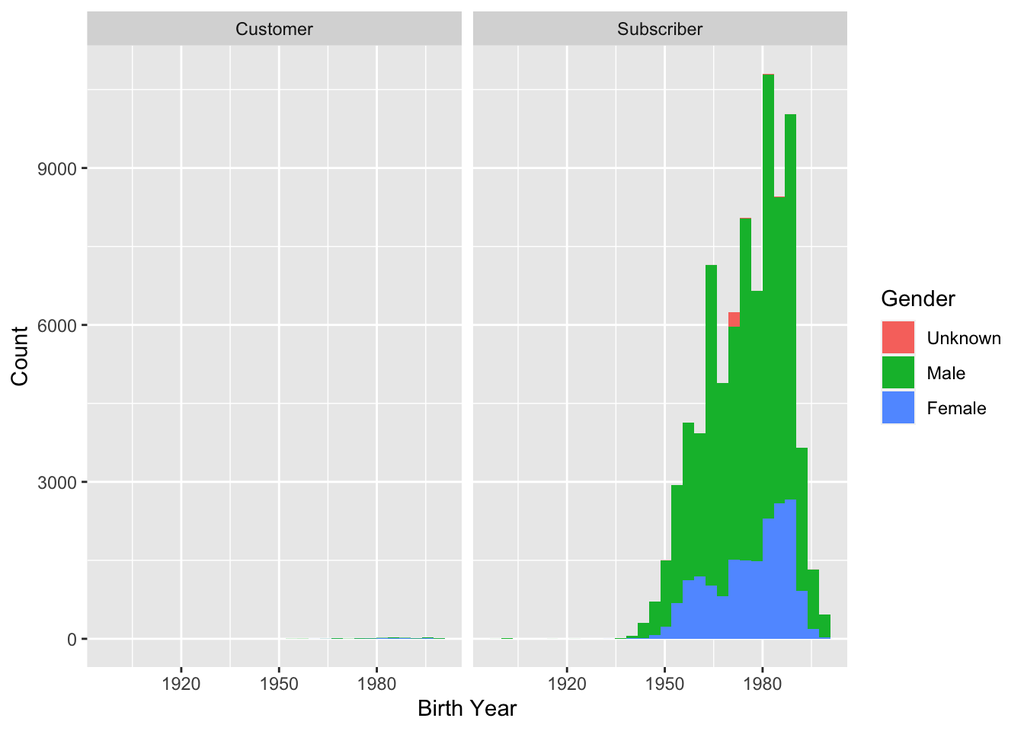

```r
library(ggplot2)
ggplot(big_bike, aes(x = `birth year`, fill = factor(gender))) + geom_histogram() +
facet_grid(. ~ usertype) +
labs(x = "Birth Year", y = "Count") +
scale_fill_discrete(name = "Gender", labels = c("Unknown", "Male", "Female"))
```

2. (2pts) First, we’re going to convert `start_date` to a `Date` variable in `R`. (By default, the `start_date` variable is classified as a `character` variable, which is common for time series datasets - but it will be more helpful to convert it to a `Date` variable.)

```r
#  convert start_date variable to Date
big_bike <- mutate(big_bike, start_date = as.Date(start_date))
```

Then, we can check what the earliest and latest dates are in the dataset:

```r
min(big_bike$start_date)
```

```
## [1] "2013-07-01"
```

```r
max(big_bike$start_date)
```

```
## [1] "2016-09-30"
```

We can see that these are July 1, 2013 and September 30, 2016, respectively.

3. (6pts) Here is how you can create the `trips_per_day` dataset (which counts the number of bike rides per day):

```r
trips_per_day <- big_bike %>%
  group_by(start_date) %>%
  summarize(n_trips = n())
```

Now let’s create a histogram of `n_trips`, i.e., the number of trips made on different days:

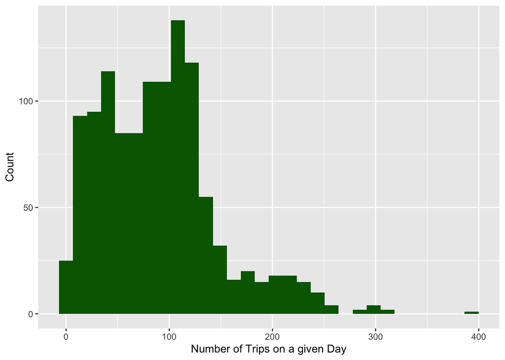

```r
ggplot(trips_per_day, aes(x = n_trips)) + geom_histogram(fill = "darkgreen") + labs(x = "Number of Trips on a given Day", y = "Count")
```

We can see that most dates have somewhere between 25 and 150 trips. However, there is a right skew to the distribution, indicating that there are some days with a very high number of trips (e.g., we see that there was one day with nearly 400 trips).

4. (6pts) Here is a plot of the number of trips across time:

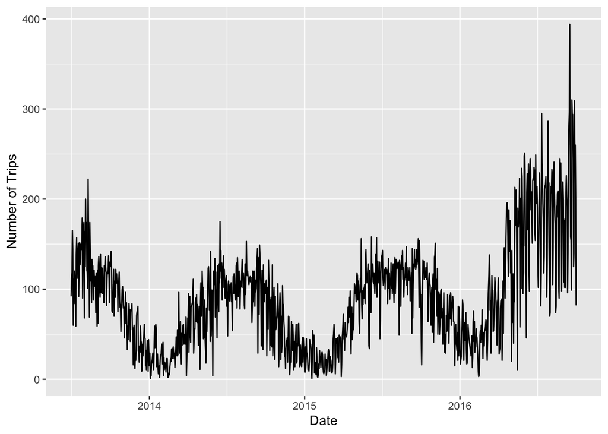

```r
ggplot(trips_per_day, aes(x = start_date, y = n_trips)) + geom_line() + labs(x = "Date", y = "Number of Trips")
```

5. (14pts) Here is how to count the number of trips, broken down by day and `usertype`:

```r
trips_per_day_usertype <- big_bike %>%
  group_by(start_date, usertype) %>%
  summarize(n_trips = n())
```

Now let’s create a time series plot for each `usertype`:

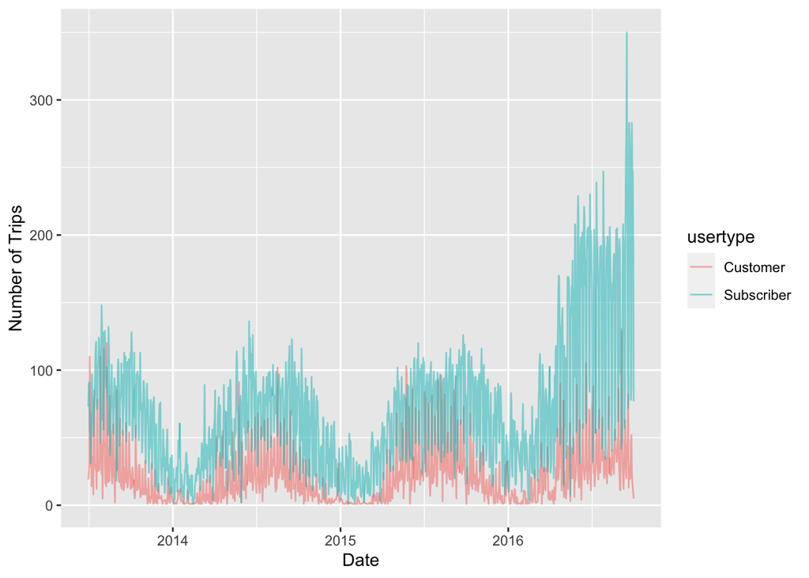

```r
ggplot(trips_per_day_usertype, aes(x = start_date, y = n_trips)) +
geom_line(data = trips_per_day_usertype, aes(color = usertype), alpha = 0.5) + labs(x = "Date", y = "Number of Trips")
```

We see that the seasonality pattern is fairly similar between “Customers” and “Subscribers.” Furthermore, we can see that more trips are consistently taken by “Subscribers.”

## Problem 3: Lags and Autocorrelation (24 points)

(6 points each)

```r
rand_ts <- rnorm(1000)
acf(rand_ts, plot = FALSE)
```

```
##
## Autocorrelations of series 'rand_ts', by lag
##
##      0      1      2      3      4      5      6      7      8      9     10
##  1.000 -0.022  0.060 -0.009 -0.050  0.016 -0.032 -0.031  0.024 -0.050 -0.010
##     11     12     13     14     15     16     17     18     19     20     21
##  0.024 -0.024  0.004  0.001  0.011  0.003 -0.016 -0.009 -0.041 -0.009 -0.011
##     22     23     24     25     26     27     28     29     30
##  0.010 -0.004  0.004 -0.002  0.005 -0.005  0.048  0.024 -0.012
```

We see that the autocorrelation for lag = 0 is 1, which is expected because this is the correlation between the time series with itself. Meanwhile, we see that the other autocorrelations tend to be around 0 - this is also expected, because we know by definition that there shouldn’t be any autocorrelation across time. Indeed, the measures are simulated iid from a Normal distribution, and thus all the measurements are independent of each other. Thus, the “true” autocorrelation for any lag should be zero, but for any given sample there will be some variation *around* zero due to random sampling.

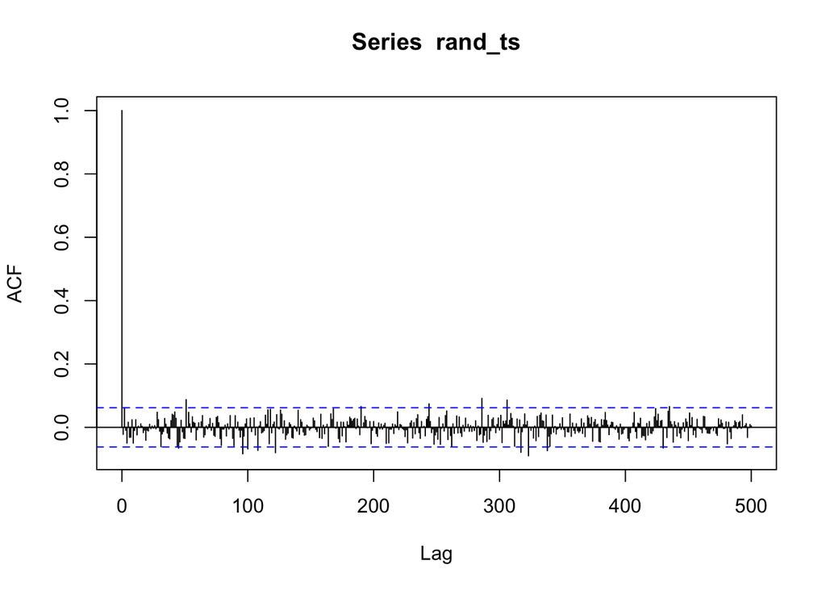

```r
acf(rand_ts, plot = TRUE, lag.max = 500)
```

Obviously the autocorrelation for lag = 0 is outside the confidence interval, but this is totally expected, as we discussed in Part A. Meanwhile, we see that there are a few random autocorrelations outside of the confidence interval. This is also totally expected: In fact, we should expect around 5% of the autocorrelations to be outside the confidence interval, because in this case we know the null hypothesis of no autocorrelation is true. This is a callback to Stat 101 material (i.e., what is a confidence interval). So, whenever you’re looking at confidence intervals across long periods of time (as in the plot above), you should take any particular observation outside the confidence interval with a grain of salt.

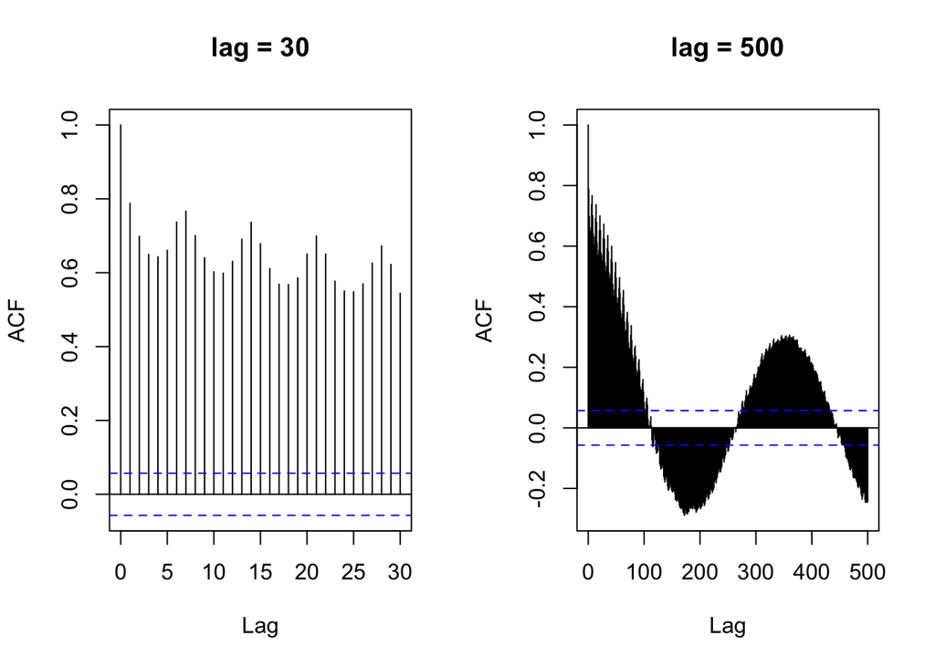

```r
par(mfrow = c(1,2))
acf(trips_per_day$n_trips, plot = TRUE, main = "lag = 30")
acf(trips_per_day$n_trips, plot = TRUE, lag.max = 500, main = "lag = 500")
```

In the left-hand plot, we see that there is very high positive correlation amongst all of the lags; we can also see a slight oscillation, probably due to a weekly seasonality trend (e.g., people may ride bikes more frequently on weekends). Meanwhile, in the right-hand plot, we see a distinct seasonality trend (likely denoting the summer-winter seasonal trend we noted in Problem 2). The point of this problem was to demonstrate that it can often be helpful to make multiple autocorrelation plots. Making the maximum lag small allows us to see local trends (like weekly seasonality), but it may also be misleading (e.g., if we only made the left-hand plot, we may think that there is only positive autocorrelation); meanwhile, making the maximum lag large allows us to see global trends, and it’s also much easier to detect where there are positive and negative correlations. Both plots provide valuable information!

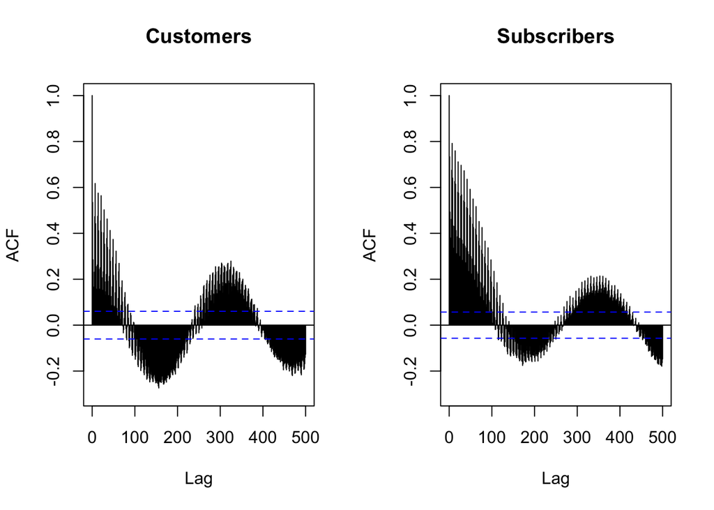

```r
par(mfrow = c(1,2))
acf(subset(trips_per_day_usertype, usertype == "Customer")$n_trips, plot = TRUE, lag.max = 500,
    ylim = c(-0.3, 1), main = "Customers")
acf(subset(trips_per_day_usertype, usertype == "Subscriber")$n_trips, plot = TRUE, lag.max = 500,
    ylim = c(-0.3, 1), main = "Subscribers")
```

There are clearly seasonality trends for both groups (customers and subscribers), and they seem to peak and valley at similar times. Perhaps the most noticeable thing is that autocorrelations “last longer” for subscribers than for customers; for example, there is a much higher positive autocorrelation for lags 0 to 100, and the autocorrelation tends to switch from positive to negative (and vice versa) at further time points for subscribers than for customers. This suggests that subscribers have “less sharp” peaks and valleys than customers - indeed, this is exactly what we see when we look back at our plot at the end of Problem 2. Overall, though, the two plots look quite similar to each other.

## Problem 4: Moving Averages (16 points)

(8 points each)

Now we’re going to make moving averages. Like the rest of this homework, it’ll be helpful to refer back to the Lecture 22 `R` Demo to see how to plot moving averages.

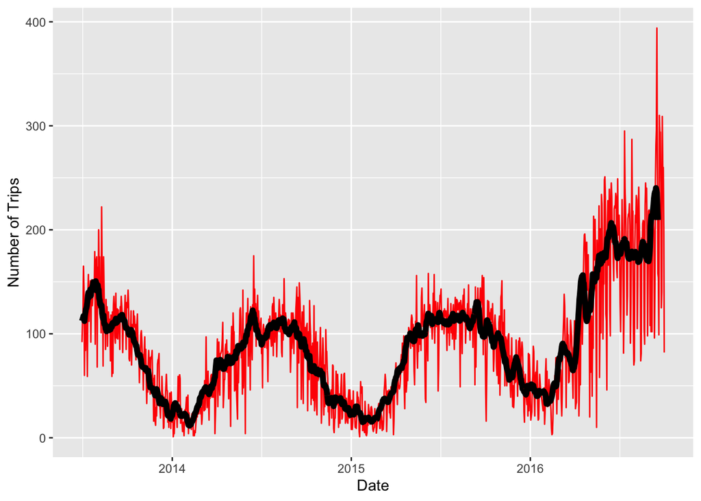

```r
library(ggseas)
ggplot(trips_per_day, aes(start_date, n_trips)) + geom_line(color="red") +
  stat_rollapplyr(width = 14, align = "left", size = 2) +
  labs(x = "Date", y = "Number of Trips")
```

We picked `width = 14` because it seems to result in a curve that fits the data well; furthermore, it has the interpretation of averaging across two-weeks’ worth of data. One could also increase `width` slightly to get a slightly smoother curve, but we found that increasing `width` too much led to a curve that did not fit the data very well.

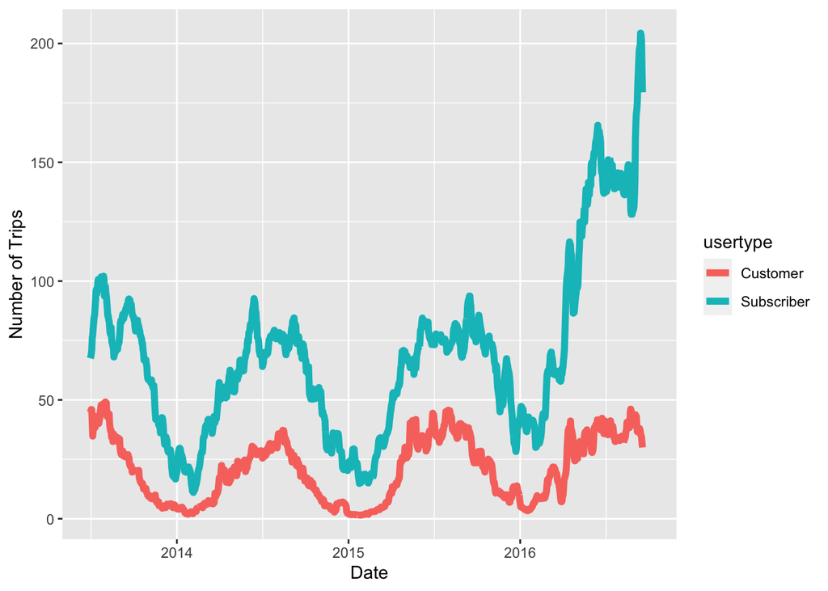

```r
ggplot(trips_per_day_usertype, aes(start_date, n_trips, color = usertype)) +
  stat_rollapplyr(width = 14, align = "left", size = 2) +
  labs(x = "Date", y = "Number of Trips")
```

The most important observation to make from this plot is that subscribers are consistently taking more trips than customers (but again, this is likely due to the fact that there are a lot more subscribers in the dataset). Interestingly, we also see an unusual spike in number of trips among subscribers in 2016 - this is likely due to more subscribers joining Citi Bike in 2016. (I’m mostly guessing here - it could also be that people suddenly started taking more bike trips per person in 2016, but that seems less likely.) The point of this problem was to show that a moving average plot like the one above is especially useful for comparing and contrasting trends for different subgroups - for example, it’s much easier to make the comparison between subscribers and customers in this plot than in the plot we made at the end of Problem 2.

## Problem 5: Seasonal Decompositions (16 points)

(8 points each)

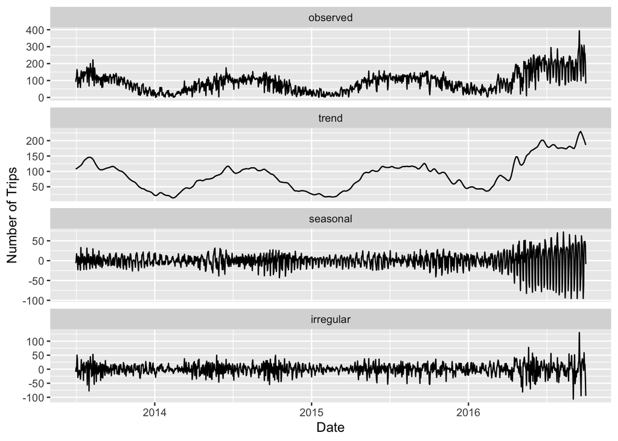

```r
ggsdc(trips_per_day, aes(start_date, n_trips),
    frequency = 14, method = "stl", s.window = 7) + geom_line() +
  labs(x = "Date", y = "Number of Trips")
```

We already saw the top plot in Problem 2D, so we won’t discuss it further. Interestingly, the “trend” plot distinctly shows what we would typically call a seasonal trend (which we also discussed in Problem 2D). Meanwhile, the “seasonal” plot appears to be picking up the small weekly oscillations that we noted in Problem 3C. Notably, there seems to be much greater variation in the “seasonal” plot after 2016 (this is likely due to the influx of subscribers after 2016, as we discussed in Problem 4). Meanwhile, there does not appear to be any clear trend in the “irregular” plot.

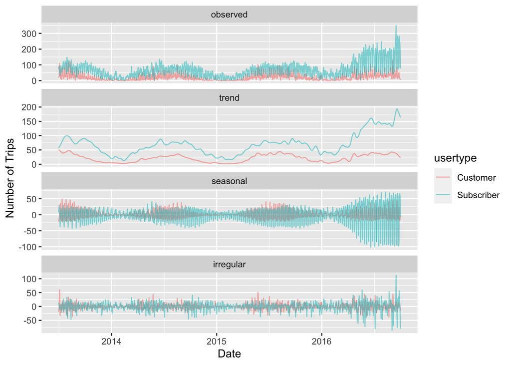

```r
ggsdc(trips_per_day_usertype, aes(start_date, n_trips, color = usertype),
    frequency = 14, method = "stl", s.window = 7) + geom_line(alpha = 0.5) + labs(x = "Date", y = "Number of Trips")
```

As discussed in the homework problem, we already saw the top plot at the end of Problem 2, and we (basically) already saw the “trend” plot at the end of Problem 4. Thus, we will not discuss these plots further here. The most defining feature of the “seasonal” plot is that the “subscribers” trend exhibits much more variation than that of “customers,” especially after 2016; this is likely due to the spike in subscribers that occurred after 2016, as discussed at the end of Problem 4. Finally, there does not appear to be any clear trend in the “irregular” plot.